# LTR and MAD Determination

Jimmy Larson

3/16/2020

## Introduction

File describes the steps to determine the maximum allowable limb diameter (MAD) for limb to trunk (LTR) pruning of Gala trees used in apple thinning multispectral imaging study.

LTR pruning sets a uniform ratio, here we selected 1.25, of limb (fruiting area) to trunk size. This was to ensure that all trees in the study, though different sizes, were pruned to the same severity level. We had 5 tree sizes within the 90 trees in the study, see class size determination file. Three trees were selected for each size class and had all primary limb’s diameter measured ~3cm from the base of the trunk on 3/6/20, n = 15.

## Tree Class Size

```r
ltr.class <- seq(trees.tcsa.min$min, trees.tcsa.max$max, length.out = 6)
ltr.class <- as.data.frame(ltr.class)
ltr.class %>%
  mutate(class.id = seq(1,6))
```

```
##   ltr.class class.id
## 1    11.650        1
## 2    13.706        2
## 3    15.762        3
## 4    17.818        4
## 5    19.874        5
## 6    21.930        6
```

## MAD Determination

A number of methods were used to determine the MAD for each tree in the study while only having to measure a portion of the total trees in the study. Initially, the MAD was determined for each tree measured by ordering the limb cross sectional areas (LCSA) from smallest to largest, calculating a running sum of LCSA with each successively larger branch, then calculating LTR by dividing the LCSA by the trunk cross sectional area (TCSA), when the LTR reached 1.25 whichever the branch diameter was was determined to be the MAD.

```
## # A tibble: 6 x 8
## # Groups:   rep, trunk.class [1]
##   trunk.class   rep limb.diam.mm limb.diam   lcsa lcsa.sum tcsa.cm     ltr
##   <chr>       <dbl>        <dbl>     <dbl>  <dbl>    <dbl>   <dbl>   <dbl>
## 1 1               1         2.29     0.229 0.0412   0.0412    12.4 0.00331
## 2 1               1         2.84     0.284 0.0633   0.105     12.4 0.00841
## 3 1               1         3.17     0.317 0.0789   0.183     12.4 0.0148
## 4 1               1         3.55     0.355 0.0990   0.282     12.4 0.0227
## 5 1               1         3.67     0.367 0.106    0.388     12.4 0.0312
## 6 1               1         3.82     0.382 0.115    0.503     12.4 0.0405
```

The MADs for each tree were therefore determined to be:

```
## # A tibble: 15 x 7
## # Groups:   ltr.class, rep [15]
##    ltr.class rep   tcsa.cm   MAD  lcsa   ltr     n
##    <chr>     <chr>   <dbl> <dbl> <dbl> <dbl> <int>
##  1 1         1        12.4  9.06  15.0  1.20    11
##  2 1         2        12.8 13.0   15.3  1.19     8
##  3 1         3        13.7 11.4   16.6  1.22     8
##  4 2         1        13.9 10.3   16.9  1.22     8
##  5 2         2        13.9 12.6   16.7  1.20     6
##  6 2         3        15.6 11.2   18.7  1.20    10
##  7 3         1        17.4 16.4   21.0  1.21     5
##  8 3         2        15.8 12.6   19.4  1.23    10
##  9 3         3        16.7 13.4   20.8  1.24     4
## 10 4         1        19.6 11.9   24.1  1.23     8
## 11 4         2        17.9 15.4   20.9  1.17     7
## 12 4         3        19.6 14.4   23.5  1.20     5
## 13 5         1        20.1 13.1   23.8  1.18    10
## 14 5         2        21.9 14.2   26.1  1.19     4
## 15 5         3        20.9 14.6   25.1  1.20     4
```

A regression equation was then determined from MAD and TCSA:

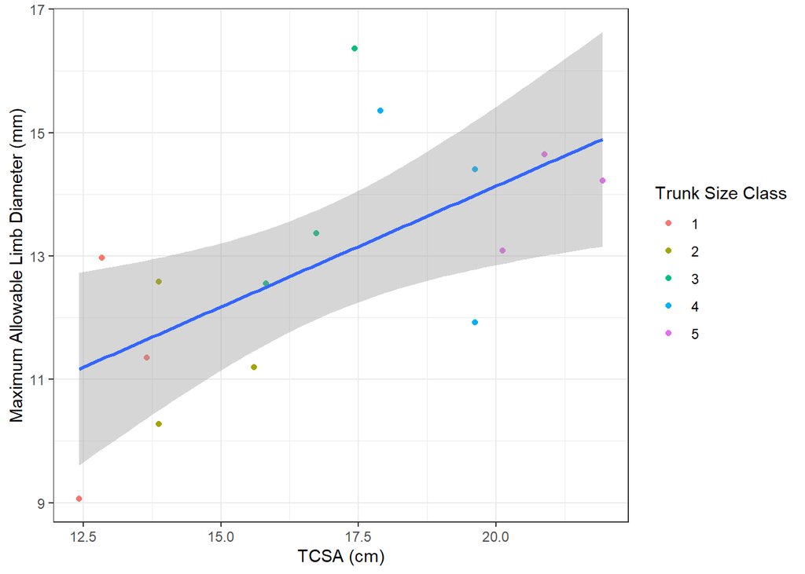

The R-squared was however poor:

```
## # A tibble: 1 x 11
##   r.squared adj.r.squared sigma statistic p.value    df logLik   AIC   BIC
##       <dbl>         <dbl> <dbl>     <dbl>   <dbl> <int>  <dbl> <dbl> <dbl>
## 1     0.391         0.344  1.58      8.35  0.0127     2  -27.1  60.2  62.3
## # ... with 2 more variables: deviance <dbl>, df.residual <int>
```

Due to the variability of the data looking at just MAD, a regression equation was made between overall limb diameter and LTR of the tree within each tree size class:

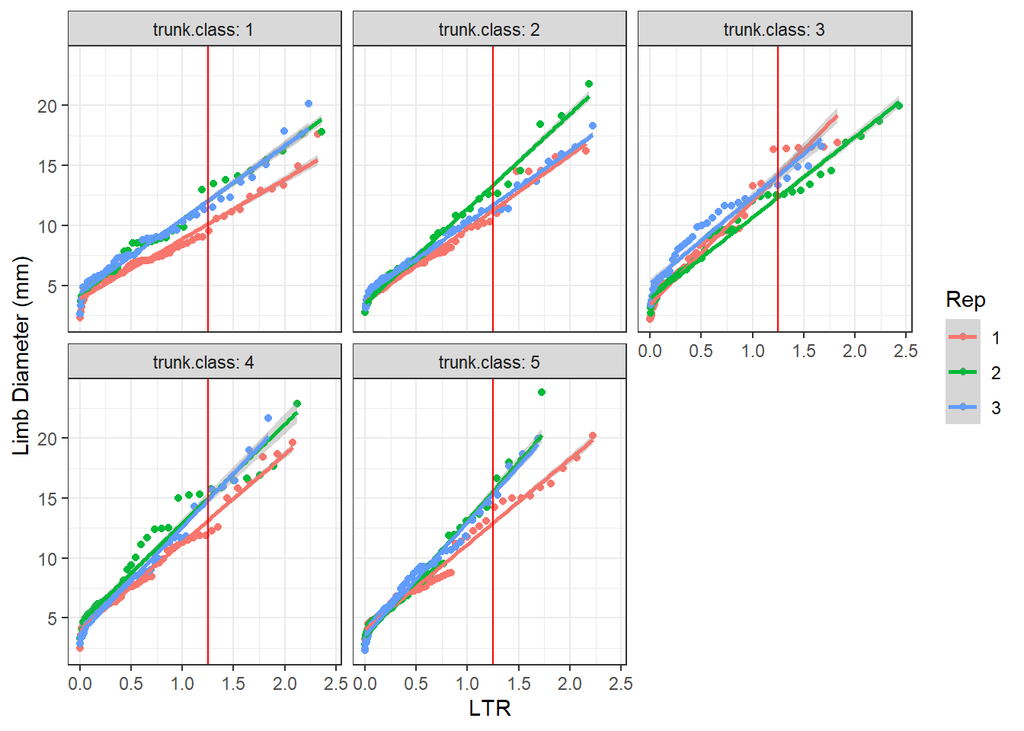

```r
limbs.ltr %>%
  filter(trunk.class == "1") -> class.1.ltr
class.1.ltr.regress <- lm(limb.diam.mm ~ ltr, data =  class.1.ltr)
limbs.ltr %>%
  filter(trunk.class == "2") -> class.2.ltr
class.2.ltr.regress <- lm(limb.diam.mm ~ ltr, data =  class.2.ltr)
limbs.ltr %>%
  filter(trunk.class == "3") -> class.3.ltr
class.3.ltr.regress <- lm(limb.diam.mm ~ ltr, data =  class.3.ltr)
limbs.ltr %>%
  filter(trunk.class == "4") -> class.4.ltr
class.4.ltr.regress <- lm(limb.diam.mm ~ ltr, data =  class.4.ltr)
limbs.ltr %>%
  filter(trunk.class == "5") -> class.5.ltr
class.5.ltr.regress <- lm(limb.diam.mm ~ ltr, data =  class.5.ltr)
```

The fit for each of these regression equations was much better:

```r
glance(class.1.ltr.regress)
```

```
## # A tibble: 1 x 11
##   r.squared adj.r.squared sigma statistic  p.value    df logLik   AIC   BIC
##       <dbl>         <dbl> <dbl>     <dbl>    <dbl> <int>  <dbl> <dbl> <dbl>
## 1     0.935         0.935 0.903     2145. 2.36e-90     2  -198.  402.  411.
## # ... with 2 more variables: deviance <dbl>, df.residual <int>
```

```r
glance(class.2.ltr.regress)
```

```
## # A tibble: 1 x 11
##   r.squared adj.r.squared sigma statistic   p.value    df logLik   AIC
##       <dbl>         <dbl> <dbl>     <dbl>     <dbl> <int>  <dbl> <dbl>
## 1     0.964         0.964 0.707     4477. 4.99e-123     2  -181.  369.
## # ... with 3 more variables: BIC <dbl>, deviance <dbl>, df.residual <int>
```

```r
glance(class.3.ltr.regress)
```

```
## # A tibble: 1 x 11
##   r.squared adj.r.squared sigma statistic  p.value    df logLik   AIC   BIC
##       <dbl>         <dbl> <dbl>     <dbl>    <dbl> <int>  <dbl> <dbl> <dbl>
## 1     0.936         0.936  1.04     2295. 1.30e-95     2  -230.  467.  476.
## # ... with 2 more variables: deviance <dbl>, df.residual <int>
```

```r
glance(class.4.ltr.regress)
```

```
## # A tibble: 1 x 11
##   r.squared adj.r.squared sigma statistic   p.value    df logLik   AIC
##       <dbl>         <dbl> <dbl>     <dbl>     <dbl> <int>  <dbl> <dbl>
## 1     0.959         0.959 0.861     3953. 1.22e-119     2  -217.  441.
## # ... with 3 more variables: BIC <dbl>, deviance <dbl>, df.residual <int>
```

```r
glance(class.5.ltr.regress)
```

```
## # A tibble: 1 x 11
##   r.squared adj.r.squared sigma statistic   p.value    df logLik   AIC
##       <dbl>         <dbl> <dbl>     <dbl>     <dbl> <int>  <dbl> <dbl>
## 1     0.952         0.952 0.884     3898. 2.59e-131     2  -255.  517.
## # ... with 3 more variables: BIC <dbl>, deviance <dbl>, df.residual <int>
```

The MAD was then determined by predicting the branch diamter at an LTR of 1.25:

```r
class.1.MAD.predict <- predict(class.1.ltr.regress, newdata = desir.ltr.df)
class.2.MAD.predict <-predict(class.2.ltr.regress, newdata = desir.ltr.df)
class.3.MAD.predict <-predict(class.3.ltr.regress, newdata = desir.ltr.df)
class.4.MAD.predict <-predict(class.4.ltr.regress, newdata = desir.ltr.df)
class.5.MAD.predict <-predict(class.5.ltr.regress, newdata = desir.ltr.df)
```

```
## # A tibble: 5 x 2
##     MAD trunk.class
##   <dbl>       <int>
## 1  11.3           1
## 2  12.0           2
## 3  13.3           3
## 4  14.2           4
## 5  14.1           5
```